# Section: Week 2

## Distributions

For more on exploring different **distributions** and their parameters check out [this app](https://gallery.shinyapps.io/dist_calc/).

## Going through $\chi^2$

Please refer to the [handout](http://www.stanford.edu/class/psych252/section/chisq-test.pdf). More details walking through the math behind a **goodness-of-fit** test and **contingency** test are available [here](http://stanford.edu/class/psych252/cheatsheets/index.html#math-behind-chi-square-tests). Also, check out [this app](https://supsych.shinyapps.io/chisq_dist) to see how p-values are calculated from the $\chi^2$ distribution with a given number of dfs!

Basically, $\chi^2$ captures the **difference** between **observed** (O) data, and that **expected (E) by chance** (or from some other *a priori* hypothesis, e.g., census data).

$\chi^2 = \sum\limits_{i=1}^n \frac{(O_i - E_i)^2}{E_i}$

For contingency tests ($i$=row number, $j$=column number): $E_{ij} = \frac{R_iC_i}{N}$

## Standard Deviation vs. Standard Error

Check out our [app on “sampling and standard error”](http://stanford.edu/class/psych252/apps/index.html#sampling-and-standard-error)! Note that the variances of the sample statistic follow a $\chi^2$ distribution!

### Standard Deviation

Let’s say that we want to calculate the mean temperature for Palo Alto. If we had access to all the temporature data ever, we could just calculate the **population mean** ($\mu$) temperature. However, we really only have access to a small sample of data. Specifically, on 6 days we observe the temperature, and thus we have a sample of 6 data points:

```r
d <- c(80, 76, 81, 72, 68, 76)
```

This sample has some variation – it’s not exactly the same temperature each day (even if the range is fairly small!). The **sample standard deviation** ($s$) gives us a good estimation of the variation in the sample. Let’s calculate the standard deviation of this sample:

```r
## calculating mean of our sample
m <- mean(d); m
```

```
## [1] 75.5
```

```r
## calculating number of observations
n <- length(d); n
```

```
## [1] 6
```

```r
## calculating standard deviation using variance
sqrt(var(d))
```

```
## [1] 4.889
```

```r
# or
s <- sd(d); s
```

```
## [1] 4.889
```

We can visualize the data too!

```
## stat_bin: binwidth defaulted to range/30. Use 'binwidth = x' to adjust this.
```

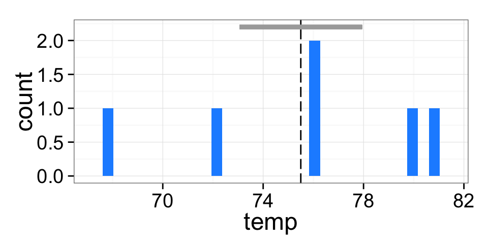

```r
library(ggplot2)

# change all ggplot backgrounds to white, increase font size
theme_set(theme_bw(base_size = 18))

temps = data.frame(temp=d)

ggplot(data=temps, aes(x=temp)) +
  geom_histogram(fill='dodgerblue') +
  geom_vline(xintercept = m, linetype = "longdash") +
  geom_segment(aes(x = m-(s/2), y = 2.2, xend = m+(s/2), yend = 2.2),
               size=1.5, colour='darkgray')
```

Now we have a good idea of the mean and standard deviation of our *sample*, and we might want to know **how good our estimate of the population mean is**. Since our sample only has 6 observations, we might not have done a great job sampling from the whole population!

### Standard error

The **standard error of the mean** (sometimes referred to as the standard deviation of the sampling distribution of the sample mean) allows us to estimate the variability of our *estimation* of the population mean ($\mu$).

```r
sem <- s/ n^.5
print(sem)
```

```
## [1] 1.996
```

```r
# this also works:
sem = s/sqrt(n)
print(sem)
```

```
## [1] 1.996
```

### Calculating confidence intervals

Now we can use the standard error of the mean to calculate a **confidence interval** for the mean!

Specifically, we want to estimate a **95% confidence interval** (CI). The **central limit theorem** says that the sampling distribution of a statistic (e.g., the sample mean; $\bar{x}$) will be approximately normal – especially if our sample size is fairly large. In our case, the distribution of sample means is approximately normal with mean $\mu$, and standard deviation equal to the standard error of the mean. So, we want to **find the interval within which** $\bar{x}$ **falls 95% of the time**.

Conveniently, since the sampling distribution of $\bar{x}$ is approximately normal, we can use the standard normal distribution to figure out this interval (as long as we have a large sample size, and know the population sd!). All the probabilities sum to 1, so that means we want to find the cutoffs where there’s only $1 - 0.95$ out in the tails of our distribution. We’ll call this $\alpha$, such that $\alpha = 1 - 0.95 = 0.05$. This will be split up between two tails, so we can divide $\alpha$ by 2 to find out how much of the distribution should be out in each tail.

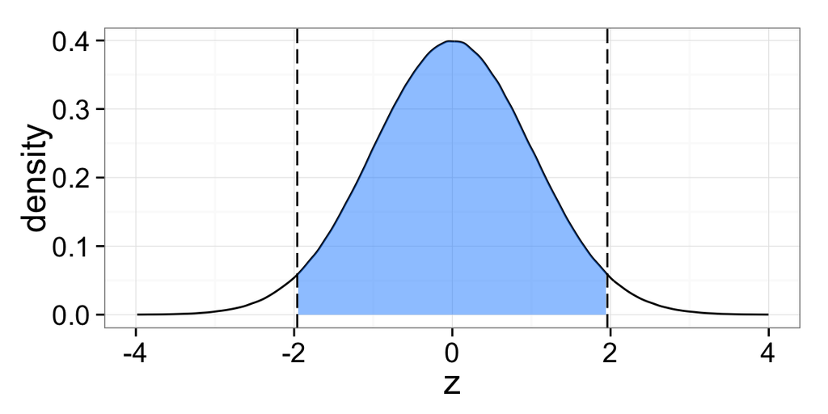

Check out [this Shiny App](https://gallery.shinyapps.io/dist_calc/) for more on distributions.

To find the **critical z value**, such that $\frac{\alpha}{2}$ lies under the curve above it, we can use the quantile function `qnorm(probability, lower.tail=FALSE)`. Then, to calculate the confidence interval of our sample mean:

$\text{Lower bound}: \bar{x} - \text{critical } z*SEM$ $\text{Upper bound}: \bar{x} + \text{critical } z*SEM$

```r
# using R to get z scores, given p
alpha = 0.05
z_critical = qnorm(alpha/2, lower.tail=FALSE); z_critical
```

```
## [1] 1.96
```

```r
ci95 <- sem * z_critical

## adding and subtracting it from mean
lowerbound = m - ci95; round(lowerbound,2)
```

```
## [1] 71.59
```

```r
upperbound = m + ci95; round(upperbound,2)
```

```
## [1] 79.41
```

#### Small sample sizes: using the $t$ distribution

However, when the sample size is pretty small (as in this case!), and we don’t know the popuation standard deviation (we’re just approximating it with the sample $s$), we should use the $t$ distribution instead of $z$. So let’s do that:

```r
# using R to get t scores, given p
alpha = 0.05
t_critical = qt(alpha/2, df = n-1, lower.tail=FALSE); t_critical
```

```
## [1] 2.571
```

```r
# note it's a little higher than our critical z!

ci95 <- sem * t_critical

## adding and subtracting it from mean
lowerbound = m - ci95; round(lowerbound,2) # here im rounding to 2 decimals when i print
```

```
## [1] 70.37
```

```r
upperbound = m + ci95; round(upperbound,2)
```

```
## [1] 80.63
```

So the confidence interval for the sample mean is from 70.37 to 80.63, which means that we are 95% confidence that the mean temperature in Palo Alto falls within this interval.

#### Some practice with q/p norm/t()

Let’s try to calculate the area under the curve to the *right* of the critical t value we just calculated:

```
## [1] 0.025
```

```
## [1] 0.025
```

Now, imagine we observed a new day when the temperature is 85 degrees. We know this is outside our 95% confidence interval of the mean, but how likely is it that we’ll observe a temperature *this hot or hotter*, based on our original sample?

```
## [1] 4.76
```

```
## [1] 0.00253
```

Now, we want to know the 99% confidence range of the mean from our original sample:

```
## [1] 67.45
```

```
## [1] 83.55
```

## Centering vs. Standardizing Data

So let’s say we have a variable “i” and want to either center or standardize it.

```r
## we have a data set with 4 variables
dn <- c(3,4,15,8)

## find mean and standard deviation for calculations
mn <- mean(dn)
print(mn)
```

```
## [1] 7.5
```

```r
sdn <- sd(dn)
print(sdn)
```

```
## [1] 5.447
```

### Centering: subtracting mean from values

```r
centered <- dn - mn; centered
```

```
## [1] -4.5 -3.5  7.5  0.5
```

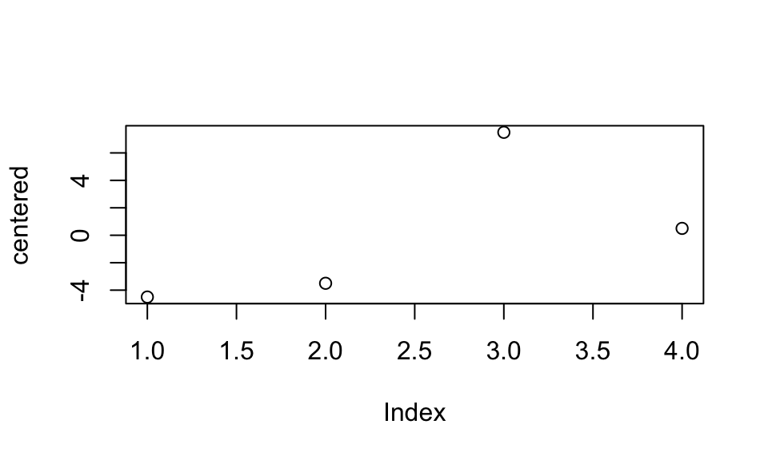

```r
plot(centered)
```

Note, there’s a helpful function that R has called `scale` – we can use this to automatically center our data, like this:

```r
centered_data = scale(dn, scale = FALSE); centered_data
```

```
##      [,1]
## [1,] -4.5
## [2,] -3.5
## [3,]  7.5
## [4,]  0.5
## attr(,"scaled:center")
## [1] 7.5
```

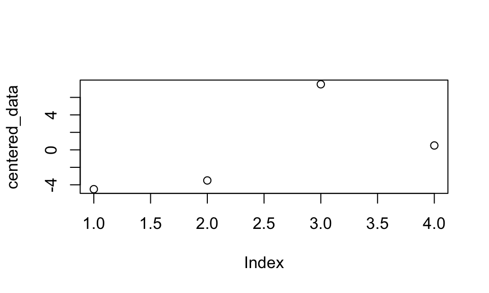

```r
plot(centered_data)
```

n.b., if you just want to center the data, set **scale = FALSE**!

Now what is our mean and standard deviation?

```r
mean(centered)
```

```
## [1] 0
```

```r
sd(centered)
```

```
## [1] 5.447
```

### Standardization: subtracting mean, dividing by standard deviation

```r
standard <- (dn-mn)/sdn; standard
```

```
## [1] -0.8262 -0.6426  1.3770  0.0918
```

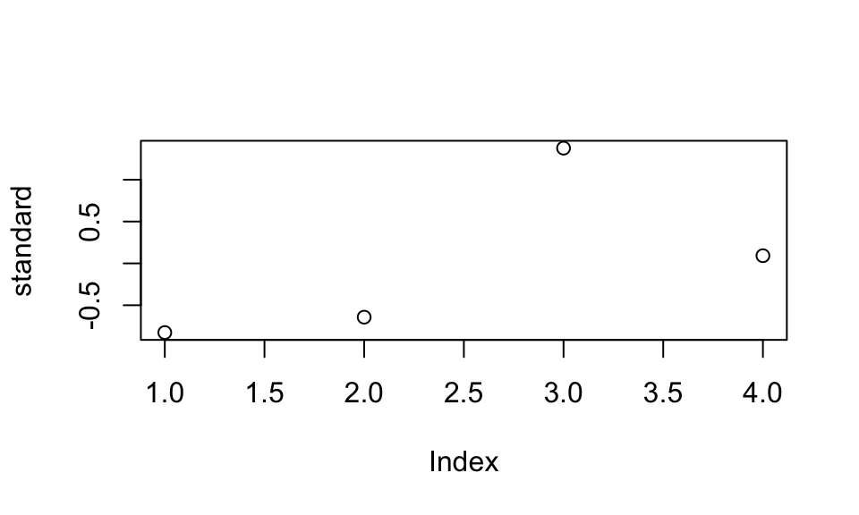

```r
plot(standard)
```

Now let’s take a look at our mean and sd…

```r
mean(standard)
```

```
## [1] -1.735e-17
```

```r
sd(standard)
```

```
## [1] 1
```

You can do this with the scale function too!

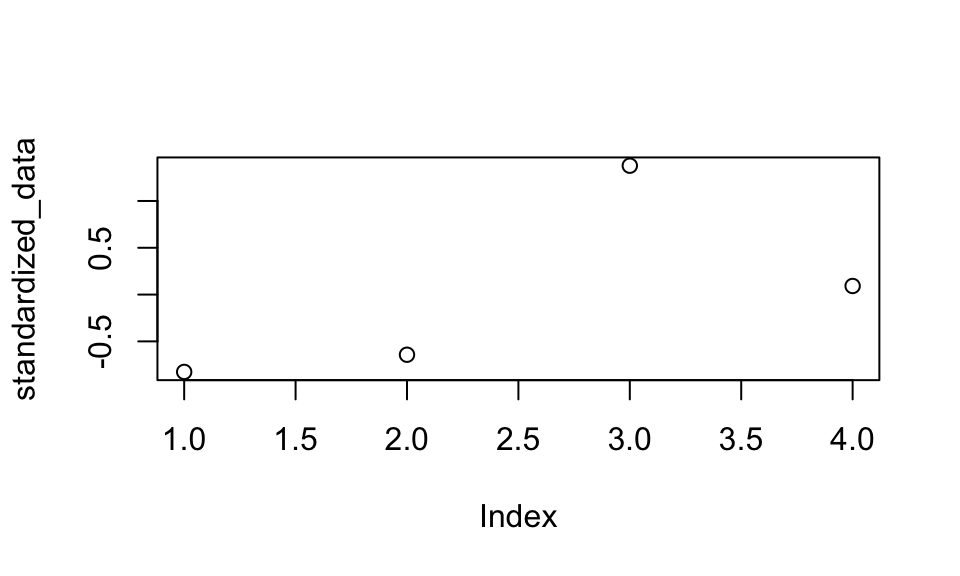

```r
standardized_data = scale(dn, scale=TRUE)
plot(standardized_data)
```

Let’s visualize these with ggplot!

```r
# made df from vectors
d = data.frame(index=1:length(dn), original=dn, centered, standard)
str(d)
```

```
## 'data.frame':    4 obs. of  4 variables:
##  $ index   : int  1 2 3 4
##  $ original: num  3 4 15 8
##  $ centered: num  -4.5 -3.5 7.5 0.5
##  $ standard: num  -0.8262 -0.6426 1.377 0.0918
```

```r
# reshape data
library(tidyr)
data_long <- gather(d, data.type, value, original:standard)
str(data_long)
```

```
## 'data.frame':    12 obs. of  3 variables:
##  $ index    : int  1 2 3 4 1 2 3 4 1 2 ...
##  $ data.type: Factor w/ 3 levels "original","centered",..: 1 1 1 1 2 2 2 2 3 3 ...
##  $ value    : num  3 4 15 8 -4.5 ...
```

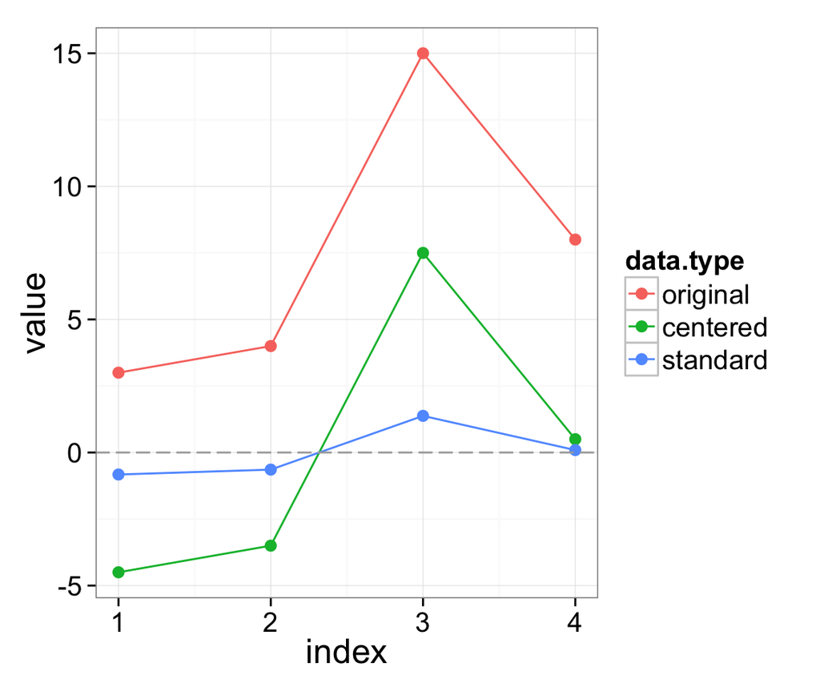

```r
# plot
ggplot(data=data_long, aes(x=index, y=value, color=data.type)) +
  geom_line() + geom_point(size=3) +
   geom_hline(x=0, color='darkgray', linetype='longdash')
```

#### Centering/standardizing dataframes

```r
# setwd
d2 = read.csv('http://www.stanford.edu/class/psych252/data/dataset_scale.csv')
```

We’re looking at a dataset of years and salary. Let’s check it out…

```r
summary(d2)
```

```
##      years           salary
##  Min.   : 1.00   Min.   : 22000
##  1st Qu.: 3.06   1st Qu.: 52250
##  Median : 5.88   Median : 63000
##  Mean   : 5.35   Mean   : 71300
##  3rd Qu.: 7.19   3rd Qu.: 80750
##  Max.   :10.00   Max.   :217000
```

```r
head(d2)
```

```
##   years salary
## 1 1.000  53000
## 2 1.375  66000
## 3 2.500  35000
## 4 2.500  55000
## 5 2.500  67000
## 6 3.250  80000
```

```r
tail(d2)
```

```
##     years salary
## 15  7.000  83000
## 16  7.750  77000
## 17  8.125 100000
## 18  8.125  83000
## 19  9.250  75000
## 20 10.000 217000
```

```r
str(d2$years)
```

```
##  num [1:20] 1 1.38 2.5 2.5 2.5 ...
```

We’re working with years here, so it doesn’t make sense to talk about expected salary when years is set to 0 - the mean is more interpretable. So we center!

Plot the data!

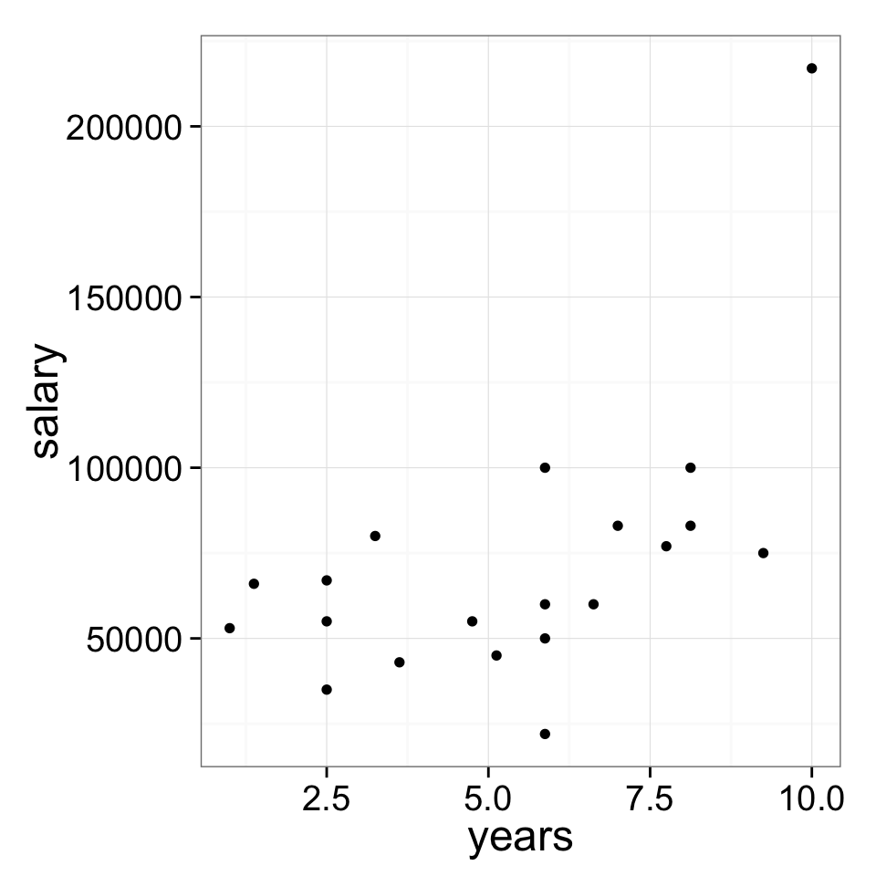

```r
ggplot(data=d2, aes(x=years, y=salary)) + geom_point()
```

##### Center the data!

```r
d2$yearsc = with(d2,scale(years, center = TRUE, scale = FALSE))
head(d2$yearsc)
```

```
##        [,1]
## [1,] -4.350
## [2,] -3.975
## [3,] -2.850
## [4,] -2.850
## [5,] -2.850
## [6,] -2.100
```

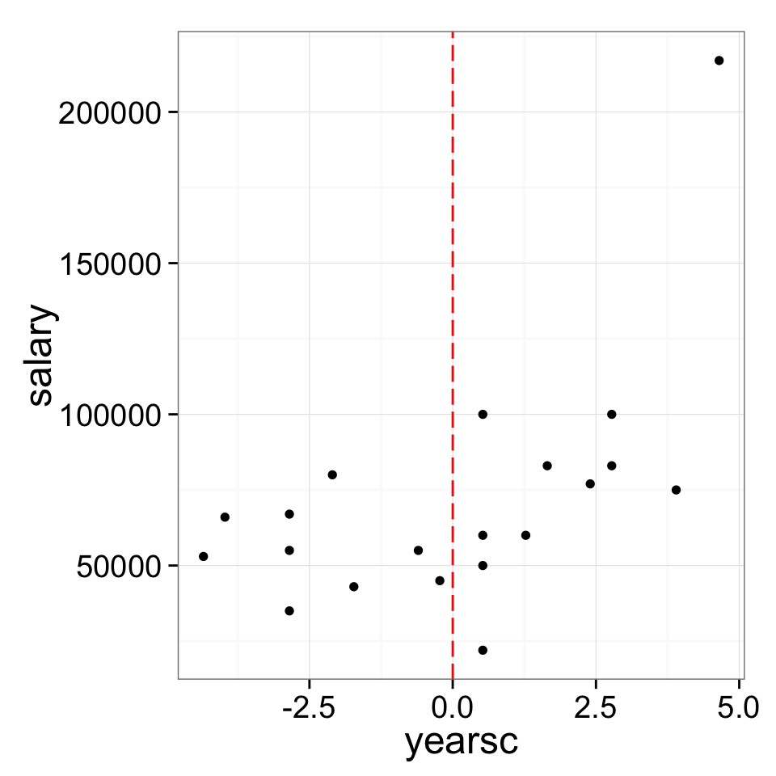

```r
ggplot(data=d2, aes(x=yearsc, y=salary)) + geom_point() +
  geom_vline(x=0, color='red', linetype='longdash')
```

##### Create standardized scores!

```r
d2$yearss = with(d2, scale(years, center = TRUE, scale = TRUE))
head(d2$yearss)
```

```
##         [,1]
## [1,] -1.6609
## [2,] -1.5177
## [3,] -1.0882
## [4,] -1.0882
## [5,] -1.0882
## [6,] -0.8018
```

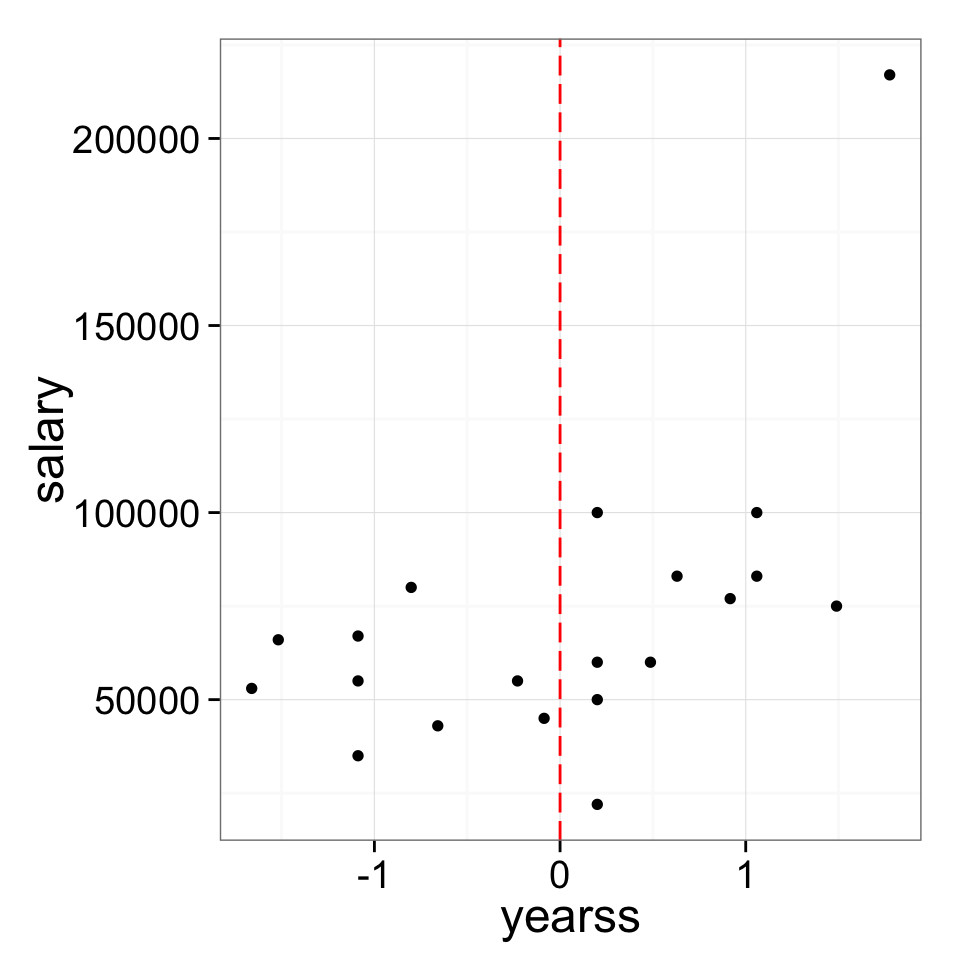

```r
ggplot(data=d2, aes(x=yearss, y=salary)) + geom_point() +
  geom_vline(x=0, color='red', linetype='longdash')
```

Now let’s reexamine our data set…

```r
summary(d2)
```

```
##      years           salary          yearsc.V1         yearss.V1
##  Min.   : 1.00   Min.   : 22000   Min.   :-4.350   Min.   :-1.6609
##  1st Qu.: 3.06   1st Qu.: 52250   1st Qu.:-2.288   1st Qu.:-0.8734
##  Median : 5.88   Median : 63000   Median : 0.525   Median : 0.2005
##  Mean   : 5.35   Mean   : 71300   Mean   : 0.000   Mean   : 0.0000
##  3rd Qu.: 7.19   3rd Qu.: 80750   3rd Qu.: 1.837   3rd Qu.: 0.7016
##  Max.   :10.00   Max.   :217000   Max.   : 4.650   Max.   : 1.7754
```

```r
sd(d2$yearsc)
```

```
## [1] 2.619
```

```r
sd(d2$yearss)
```

```
## [1] 1
```

Note that the **means** = 0, but the standard deviations are different!

##### Effects on `lm()`

Does this affect our output from `lm()`?

```r
# non normalized
rs1 = lm(d2$salary~d2$years)
summary(rs1)
```

```
##
## Call:
## lm(formula = d2$salary ~ d2$years)
##
## Residuals:
##    Min     1Q Median     3Q    Max
## -53746 -17334 -11510  18864 106319
##
## Coefficients:
##             Estimate Std. Error t value Pr(>|t|)
## (Intercept)    25991      17645    1.47    0.158
## d2$years        8469       2977    2.85    0.011 *
## ---
## Signif. codes:  0 '***' 0.001 '**' 0.01 '*' 0.05 '.' 0.1 ' ' 1
##
## Residual standard error: 34000 on 18 degrees of freedom
## Multiple R-squared:  0.31,   Adjusted R-squared:  0.272
## F-statistic: 8.09 on 1 and 18 DF,  p-value: 0.0107
```

```r
# centered
rs2 = lm(d2$salary~d2$yearsc)
summary(rs2)
```

```
##
## Call:
## lm(formula = d2$salary ~ d2$yearsc)
##
## Residuals:
##    Min     1Q Median     3Q    Max
## -53746 -17334 -11510  18864 106319
##
## Coefficients:
##             Estimate Std. Error t value Pr(>|t|)
## (Intercept)    71300       7599    9.38  2.4e-08 ***
## d2$yearsc       8469       2977    2.85    0.011 *
## ---
## Signif. codes:  0 '***' 0.001 '**' 0.01 '*' 0.05 '.' 0.1 ' ' 1
##
## Residual standard error: 34000 on 18 degrees of freedom
## Multiple R-squared:  0.31,   Adjusted R-squared:  0.272
## F-statistic: 8.09 on 1 and 18 DF,  p-value: 0.0107
```

```r
# standardized
rs3 = lm(d2$salary~d2$yearss)
summary(rs3)
```

```
##
## Call:
## lm(formula = d2$salary ~ d2$yearss)
##
## Residuals:
##    Min     1Q Median     3Q    Max
## -53746 -17334 -11510  18864 106319
##
## Coefficients:
##             Estimate Std. Error t value Pr(>|t|)
## (Intercept)    71300       7599    9.38  2.4e-08 ***
## d2$yearss      22181       7796    2.85    0.011 *
## ---
## Signif. codes:  0 '***' 0.001 '**' 0.01 '*' 0.05 '.' 0.1 ' ' 1
##
## Residual standard error: 34000 on 18 degrees of freedom
## Multiple R-squared:  0.31,   Adjusted R-squared:  0.272
## F-statistic: 8.09 on 1 and 18 DF,  p-value: 0.0107
```

Note the **change in estimates** for the last part, but that **significance** never changes. Note also the **intercepts**.

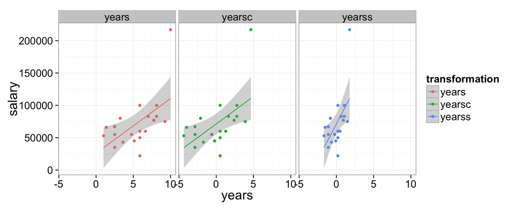

### Differences between normalizing data and normal distributions

Standardizing data doesn’t fix problems of skewness. Let’s take a look at a skewed distribution

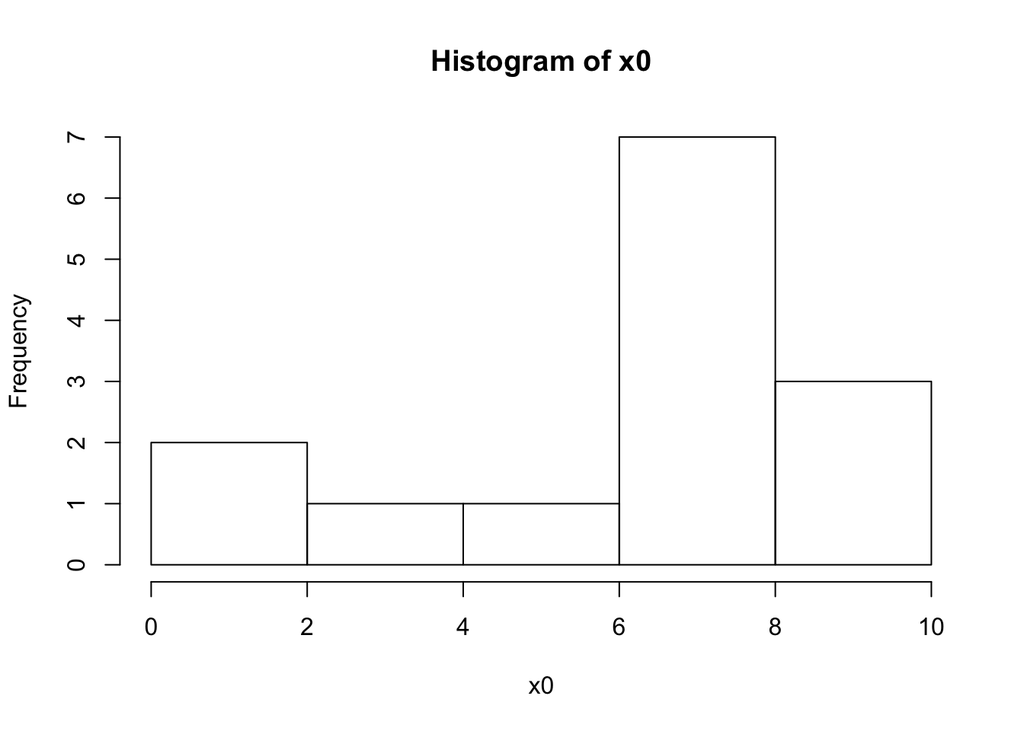

```r
x0 = c(1:3, 5, 7, 7, 7, 8, 8, 8, 8, 9, 9, 9)
hist(x0)
```

```r
msk = mean(x0); msk
```

```
## [1] 6.5
```

```r
sdsk = sd(x0); sdsk
```

```
## [1] 2.682
```

```r
## load psych library, test for skewness
# install.packages('psych')
library(psych)
skew(x0)
```

```
## [1] -0.8999
```

Now let’s standardize…

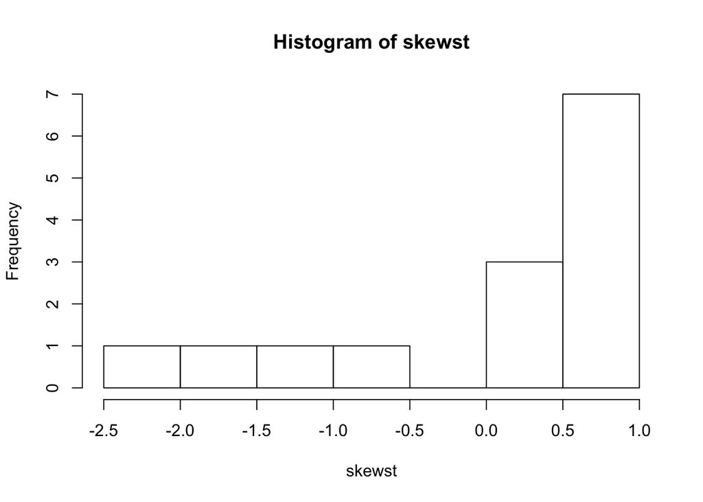

```r
skewst = (x0-msk)/sdsk

hist(skewst)
```

```r
## now we can see that the mean and SD are at 0 and 1
mean(skewst)
```

```
## [1] 5.878e-18
```

```r
sd(skewst)
```

```
## [1] 1
```

```r
## BUT the plot looks exactly the same -- the data is still skewed!
skew(skewst)
```

```
## [1] -0.8999
```

## $t$-tests and the null hypothesis

Just as a quick historical note, the $t$-test was introduced by William Gosset, a chemist at Guiness in Ireland, working to come up with a cheap way to monitor the quality of Guiness beer! Guiness brewery made him publish with a pen name, and his name was “Student”, hence “Student’s t-test”!

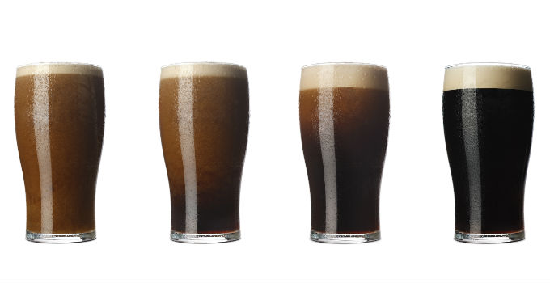

Let’s generate a distribution that represents the null.

```r
## generating random data
group = rnorm(10000, mean=0, sd=1)
```

Let’s plot this distribution.

```
## stat_bin: binwidth defaulted to range/30. Use 'binwidth = x' to adjust this.
```

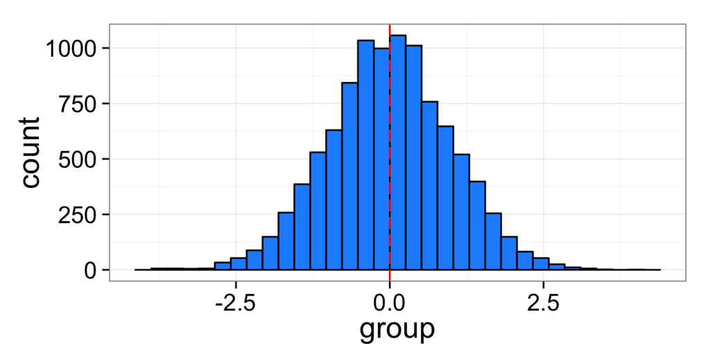

```r
ggplot(data=data.frame(group), aes(x=group))+
  geom_histogram(fill='dodgerblue', color='black') +
  geom_vline(x=0, linetype='longdash', color='red')
```

Let’s do a t.test – is this different from 0?

```r
t.test(group)
```

```
##
##  One Sample t-test
##
## data:  group
## t = -0.8104, df = 9999, p-value = 0.4177
## alternative hypothesis: true mean is not equal to 0
## 95 percent confidence interval:
##  -0.02760  0.01146
## sample estimates:
## mean of x
## -0.008074
```

Taking samples from the population distribution

```r
samp1 = sample(group, size=10, replace=F)
samp1
```

```
##  [1]  0.37594 -0.13162 -1.02772  0.39040 -0.35312 -0.99690 -1.05957
##  [8]  0.08867  0.65633 -0.36970
```

```r
t.test(samp1)
```

```
##
##  One Sample t-test
##
## data:  samp1
## t = -1.215, df = 9, p-value = 0.2554
## alternative hypothesis: true mean is not equal to 0
## 95 percent confidence interval:
##  -0.6948  0.2094
## sample estimates:
## mean of x
##   -0.2427
```

If we took 1000 samples from this distribution:

```r
scores = group
R = 1000
t.values = numeric(R)

for (i in 1:R) {
groups = sample(scores, size=100, replace=T)
t.values[i] = t.test(groups)$statistic
}
```

Plotting t values!

```r
critical_t = qt(p = 0.05/2, df = 99, lower.tail = FALSE); critical_t
```

```
## [1] 1.984
```

```
## stat_bin: binwidth defaulted to range/30. Use 'binwidth = x' to adjust this.
```

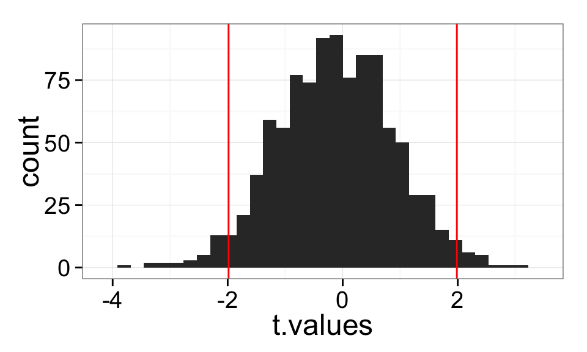

```r
ggplot(data=data.frame(t.values), aes(t.values)) + geom_histogram() +
  geom_vline(x=c(critical_t, -critical_t), color='red')
```

Some t-values that fall outside of the range!

#### Let’s visualize what a one-sample t-test is doing!

$t = \frac{\bar{x}-\mu}{\frac{s}{\sqrt{n}}}$

```r
m = 2
s = 2
n = 20
alpha = 0.05
critical_tstat = qt(alpha/2, df=n-1, lower.tail=FALSE); print(critical_tstat)
```

```
## [1] 2.093
```

```r
sterr = s/sqrt(n); sterr
```

```
## [1] 0.4472
```

```r
t_statistic = (m-0)/sterr; t_statistic
```

```
## [1] 4.472
```

```r
pval = pt(q = t_statistic, df = n-1, lower.tail = FALSE); pval
```

```
## [1] 0.0001306
```

```r
upper = m + critical_tstat*sterr; upper
```

```
## [1] 2.936
```

```r
lower = m - critical_tstat*sterr; lower
```

```
## [1] 1.064
```

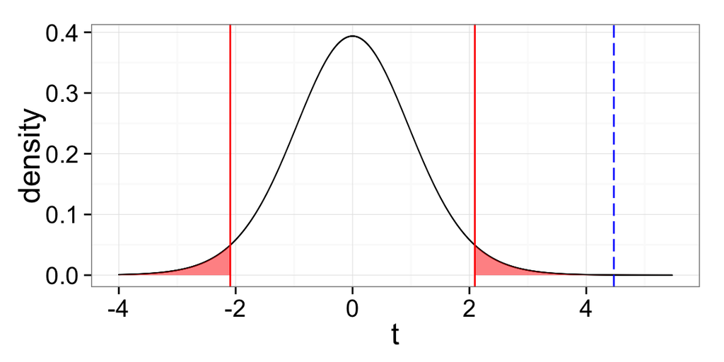

#### Visualizing the sample, 95% confidence interval, and $t$ statistic

Let’s look at an example here, where our null hypothesis is that age on a playground is 4 years old, and our alternate hypothesis is that it is 6 years old.

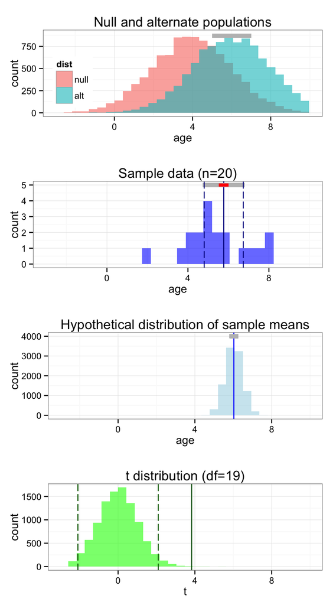

## Power

Power is the **ability of a test to detect an effect**, given that the effect exists (i.e., that the alternate hypothesis is true). In other words:

$\text{Power} = P(\text{reject }H_0| H_a \text { is true}) = 1- \beta$

We can estimate the **distributions** of the null ($H_0$) and the alternate ($H_a$) hypotheses, and figure out the probability of “accepting” the alternate hypothesis, given that it’s true. That is, we want to find the **area under the curve** of the **alternate hypothesis** to the *right* of the critical cutoff for the null hypothesis (our $\alpha$ region; more specifically $\frac{\alpha}{2}$ if it’s a 2-tailed test!). Often power is described in terms of Type II error. **Type I error** is “false positives” – the probability of rejecting the null, given that it’s true; this is also our $\alpha$ region$. On the other hand, **Type II error** is “false negatives” – the probability of retaining the null, given that the alternate hypothesis is actually true. This region is the area under the $H_a$ distribution to the left of the cutoff; basically where we’d retain the null. Since the area under the density curve sums to 1, we know that the area under the $H_A$ curve where we’d *correctly* reject the null is $1-\beta$, and **that’s our power**!

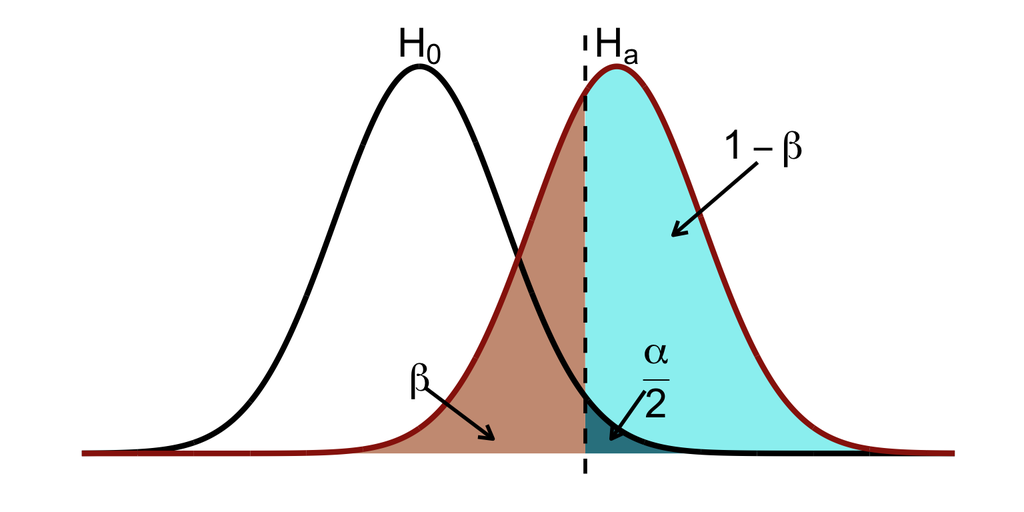

### Conceptual walkthrough of power

First, let’s determine a null distribution and its 95% CI:

```r
alpha = 0.05

null_mean <- 5
sample_s <- 1.5
sample_n <- 36

sterr = sample_s/sqrt(sample_n)

critical_t = qt(alpha, df=sample_n-1, lower.tail=FALSE); print(critical_t)
```

```
## [1] 1.69
```

```r
# if 2-sided
#critical_t = qt(alpha/2, df=sample_n-1, lower.tail=FALSE); print(critical_t)

# 95% CI around null mean
m_error = critical_t*sterr; print(m_error)
```

```
## [1] 0.4224
```

```r
null_lower = null_mean - m_error; null_lower
```

```
## [1] 4.578
```

```r
null_upper = null_mean + m_error; null_upper
```

```
## [1] 5.422
```

So, we basically want to find the area that’s under our $H_a$ curve, to the right of the critical region defined from the null distribution (though also there might be some *slight* chance of rejecting the null on the left side if we have a 2-sided test).

$P(\bar{x} > cutoff | H_a \text{ is true})$

We can get this by converting the lower/upper bounds on the null distribution into $t$-scores (i.e., standardizing the cutoffs) relative to the alternate hypothesis mean, and then we can use the $t$ distribution to figure out the area under the alternate hypothesis curve that’s *not* within the null 95% CI (this will mostly be the region > the upper bound)!

```r
delta = .7 # difference between null and alternate hypothesis means
alt_mean = null_mean + delta; print(alt_mean)
```

```
## [1] 5.7
```

```r
# if alternative hypothesis true, calculate tscores for null lower/upper bounds
tscore_lower = (null_lower-alt_mean) / sterr
tscore_upper = (null_upper-alt_mean) / sterr

# this gives us the area under Ha that's within the 95% CI of H0
beta = pt(tscore_upper, df = sample_n-1)

# if 2-sided
# beta = pt(tscore_upper, df = sample_n-1) - pt(tscore_lower, df = sample_n-1)

print(beta)
```

```
## [1] 0.1372
```

```r
# Just subtract this from 1 to get the power -- when we would reject H0
power = 1-beta; power
```

```
## [1] 0.8628
```

### Using an R function for power calculations:

Doing this same calculation in one line:

```r
power.t.test(n=sample_n,delta=delta,sd=sample_s,sig.level=0.05,
             type="one.sample",alternative="one.sided")
```

```
##
##      One-sample t test power calculation
##
##               n = 36
##           delta = 0.7
##              sd = 1.5
##       sig.level = 0.05
##           power = 0.8644
##     alternative = one.sided
```

```r
             #alternative="two.sided")
```

What else can this function do?

```r
power.t.test(delta=1.5,sd=s,sig.level=0.05,power=.8, type="one.sample",alternative="two.sided") #80% power
```

```
##
##      One-sample t test power calculation
##
##               n = 15.98
##           delta = 1.5
##              sd = 2
##       sig.level = 0.05
##           power = 0.8
##     alternative = two.sided
```

```r
power.t.test(delta=1.5,sd=s,sig.level=0.05,power=.9, type="one.sample",alternative="two.sided") #90% power
```

```
##
##      One-sample t test power calculation
##
##               n = 20.7
##           delta = 1.5
##              sd = 2
##       sig.level = 0.05
##           power = 0.9
##     alternative = two.sided
```